# Midterm

Gabriel Young

June 7, 2017

# Question 1: Character Data

The file *rich.html* on the Canvas page is a listing of the 100 richest people in America, according to Forbes magazine (from 2013), which I scraped from *Forbes.com*. We will use the file to practice working with character data. The file *rich_dataframe.txt* is formatted version of the data in the *.html* file.

1. Please load *rich.html* onto your computer using *readLines()* and save it as *rich*. Load *rich_dataframe.txt* using the appropriate command so that it’s a data frame in R and save it as *rich_df*.

```r
rich <- readLines("rich.html")
rich_df <- read.table("rich_dataframe.txt", header = TRUE, as.is = TRUE)
```

2. Your task is to extract the net worths of people listed in *rich*. The lines that contain the net worths look like the following:

`"\t\t<td class=\"worth\">$##,# B</td>"`

except with the # values are replaced by digits. For example, the first two lines which hold Bill Gates’ and Warren Buffet’s net worth are

`"\t\t<td class=\"worth\">$72 B</td>"`

`"\t\t<td class=\"worth\">$58,5 B</td>"`

You can find the location of these lines by running the following command:

`worth_lines <- grep("td class=\"worth\"", rich)`

To convince yourself, make sure the length of the above output is indeed 100.

```r
worth_lines <- grep("td class=\"worth\"", rich)
length(worth_lines)
```

```
## [1] 100
```

Your first step is to create a vector called *networths* that holds the values of net worths recorded in *rich*, in the same format. The first two values of your vector should be `$72 B` and `$58,5 B` and it should be of length 100. At the end, run the following command *networths[1:5]*.

```r
networths <- gregexpr("\\$[0-9]+,?[0-9]? B", rich[worth_lines])
networths <- unlist(regmatches(rich[worth_lines], networths))
length(networths)
```

```
## [1] 100
```

```r
networths[1:5]
```

```
## [1] "$72 B"   "$58,5 B" "$41 B"   "$36 B"   "$36 B"
```

3. The Forbes website writes net worths in the form ``$75,5 B" to mean $75,500,000,000$ dollars or 75.5 billion dollars.

Write code to convert from the Forbes format in your *networths* vector to numbers (in billions), and run it to create a numeric vector of net worths, called *networths2*. (If you are unable to create a *networths* vector in part (b), use the column *rich_df$Networths* as your starting point.) The first two values of your vector should be the numbers 72 and 58.5 and the vector should be of length 100. At the end, run the following commands *networths2[1:5]* and *identical(networths2, rich_df$Worth)*.

```r
networths2 <- substring(networths, 2, nchar(networths)-2)
networths2 <- strsplit(networths2, ",")
networths2 <- sapply(networths2, paste, collapse = ".")
networths2 <- as.numeric(networths2)

networths2[1:5]
```

```
## [1] 72.0 58.5 41.0 36.0 36.0
```

```r
identical(networths2, rich_df$Worth)
```

```
## [1] TRUE
```

```r
rich_df$MyWorth <- networths2
head(rich_df)
```

```
##   Rank                    Name Age Networths Worth             Location
## 1    1              Bill Gates  58     $72 B  72.0   Medina, Washington
## 2    2          Warren Buffett  84   $58,5 B  58.5      Omaha, Nebraska
## 3    3           Larry Ellison  70     $41 B  41.0 Woodside, California
## 4    4            Charles Koch  78     $36 B  36.0      Wichita, Kansas
## 5    5              David Koch  74     $36 B  36.0   New York, New York
## 6    6 Christy Walton & family  59   $35,4 B  35.4     Jackson, Wyoming
##             Industry Technology MyWorth
## 1          Microsoft          1    72.0
## 2 Berkshire Hathaway          0    58.5
## 3             Oracle          1    41.0
## 4        diversified          0    36.0
## 5        diversified          0    36.0
## 6           Wal-Mart          0    35.4
```

# Question 2: Plotting and KNN Classification

This question uses the data frame *rich_df* you imported in the previous question.

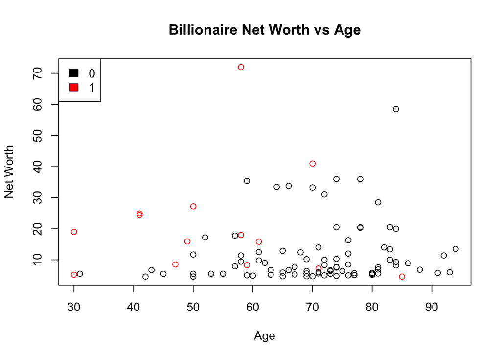

```r
plot(rich_df$Age, rich_df$Worth, xlab = "Age", ylab = "Net Worth", main = "Billionaire Net Worth vs Age", col = factor(rich_df$Technology))
legend("topleft", legend = levels(factor(rich_df$Technology)), fill = 1:length(levels(factor(rich_df$Technology))))
```

2. This data is from 2013 and so isn’t the most up-to-date. Let’s imagine a new billionaire has come on the scene and we know that she is 55 years old and worth 30 billion. Let’s add a new point to the graph that represents her. So your tasks are the following:

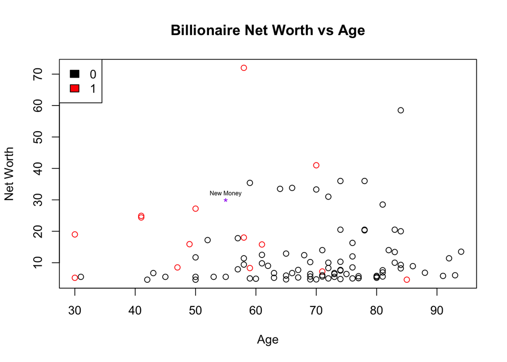

```r
plot(rich_df$Age, rich_df$Worth, xlab = "Age", ylab = "Net Worth", main = "Billionaire Net Worth vs Age", col = factor(rich_df$Technology))
legend("topleft", legend = levels(factor(rich_df$Technology)), fill = 1:length(levels(factor(rich_df$Technology))))
points(55, 30,  pch = "*", col = "purple")
text(55, 30 + 2, "New Money", cex = .5)
```

3. Let’s also imagine that we don’t know whether the new millionaire’s industry is technology or not and we’d like to make a prediction using a KNN Classification scheme. Suppose that the Euclidean distances between the new point and the points in the *rich_df* dataset are stored in a vector called *dists* (meaning the first value in *dists* in the distance between the new point and Bill Gates’ point, the second value in *dists* in the distance between the new point and Warren Buffet’s point, and so on).

Now suppose we have the following information:

`> head(order(dists), 10)`

`[1] 12 6 8 7 22 21 23 13 14 25`

`> tail(order(dists), 10)`

`[1] 46 98 60 2 37 1 29 71 68 50`

Using the above information, what would be the predicted classification if we were using a KNN classifier with $K=7$. You don’t need to write code that outputs the answer, but you should need a line or two of code to give you enough information to find the answer.

```r
K.nearest.neighbs <- c(12, 6, 8, 7, 22, 21, 23)
rich_df$Technology[K.nearest.neighbs]
```

```
## [1] 1 0 0 0 0 1 0
```

So we classify the new point as a 0, or not in the technology industry.